# Reverse Electrodialysis: A Feasibility and Optimization Analysis

### Final Project: CBE 30356

### Soren Kyhl, Rhys Forsyth and Kevin Weaver

### 5-10-2016

This project optimizes the design of a Reverse Electrodialysis (RED) power generation plant.

In Part 1, osmotically driven flow through a porous membrane will be modelled in order to determine the optimal pore radius which results in the highest efficiency conversion of hydrodynamic energy to electric power output (streaming potential).

In Part 2, Flow through parallel channels is modelled in order to determine the optimal flowrate and channel width which result in maximum net power output per unit area.

Finally, An analysis of scale and feasibility will be made in light if the results in order to draw conclusions about the promise of RED as a source of renewable energy.

### Initialize Libraries

```python
%matplotlib inline
import numpy as np
import sympy as sym
import matplotlib.pyplot as plt
from scipy.integrate import odeint
sym.init_printing(use_latex = True)
from IPython.display import display
```

### Constants

```python
ep = 8.854187e-12  # Farad/m   (permittivity of vaccum)
F = 96485.3329     # C/mol     (Faraday's constant)
R = 8.314          # J/molK    (Gas Constant)
T = 273+25         # K         (Uniform system temperature)
z = 1              # unitless  (valency, 1 for NaCl solution)
mu = 8.90e-4       # Pa*s      (viscosity of water)
L = 1/1000         # m         (thickness of membrane, 1mm)
D = 1.612e-9       # m^2/s     (Diffusivity of NaCl in Water, infinite Dilution. Source: probstein, p25)

sym.var('a')       # pore size, variable

Area = 1           # m^2       (membrane area)
l = np.sqrt(Area)  # m         (channel length)
h = np.sqrt(Area)  # m         (channel height)
pore = (2*a)**2    # m^2/pore  (area of one pore)
npores = Area/pore # pores     (number of pores)

Cf = 0.001*1000    #mol/m^3    (Concentration of fresh water stream, 0.001 mM)
Cs = 1*1000        #mol/m^3    (Concentration of salt water stream, 1 M)
```

# Part 1: Optimize Pore Radius

## 1a) Model Pressure-Driven Flow through Cylindrical Pore

Flow through a cylindrical pipe can be modelled by the Navier-Stokes Equation in cylindrical coordinates with no-slip boundary conditions at the pore surface and symmetry about the central axis.
$$ u(r) = u_{max} \left(1 - \left(\frac{r}{a}\right)^2\right) $$ $$ $$ $$ u_{max} = \frac{\Delta P a^2}{4\mu L} $$

Velocity in the Debye layer will be approximated by a constant: $$ u_{debye} = \frac{1}{2} \frac{\lambda}{a} u_{max}$$

Flow is driven by osmotic pressure, which may be calculated with: $$\Delta P = \pi = \frac{RT}{V}x_{salt}$$

```python
# Model Osmotic Pressure
def P_osm(Csalt):
    V = 18.03/1000/1000            # mL/mol         (Molar volume of water)
    Cwater = 55.5*1000             # mol/m^3        (concentration of water: 55.5 mol/L)
    xsalt = Csalt/(Cwater+Csalt)   # dimensionless  (salt mole fraction)
    dP = R*T/V*xsalt               # Pa             (osmotic Pressure)

    return dP

dP = P_osm(Cs)

# Model Pressure Driven Flow:
Q = dP*np.pi*a**4/(8*mu*L)     # m^3/s   (Volumetric Flowrate)
umax = dP*a**2/(4*mu*L)        # m/s     (maximum fluid velocity)

Pprint = dP*10**-6             # Mpa     (osmotic pressure)
print('Osmotic Pressure is {:.3f} MPa' .format(Pprint))
```

```
Osmotic Pressure is 2.432 MPa
```

## 1b) Calculate Debye Length

The debye length in the pore is a function of bulk concentration: $$ \lambda = \left(\frac{\epsilon R T}{2 F^2 C_{inf}}\right)^{0.5} $$ $$ $$ The bulk concentration on the interior of the pore is determined by two opposing phemomenon: Diffusion of ions from the saltwater stream to the freshwater stream, and convective transport of ions due to osmotic flow in the opposite direction. Diffusive forces make the concentration in the pore approach Cs (saltwater), while convective forces make the concentration in the pore approach Cf (freshwater)

From scaling theory, calculation of a Peclet number (using the fluid velocity in the center of the pore, length of pore, and diffusivity of NaCl ions in water) indicates that convective flow dominates over diffusion of ions in the opposite direction. $$ $$ $$ Pe = \frac{U_{max} L}{D} >> 1$$ $$ $$ As a result, the bulk concentration in the pore will be dominated by convective forces and will have approximately the same composition as the fresh water stream. Furthermore, the debye length will be approximated as constant throughout the length of the pore.

```python
# Scaling theory: calculate Peclet Number
Pe = umax.evalf(subs={a:20e-9})*L/D   # dimensionless (Peclet Number)
print('Peclet number is {:.2f}' .format(Pe))

# Debye Length
lam2 = (ep*R*T/(2*(F**2)*Cf))**0.5
lam = 9.61e-9/(Cf)**0.5
print('the debye length is',lam*10**9, 'nm')

# Velocity in debye layer
u = 0.5*lam/a*umax
```

```
Peclet number is 169.52
the debye length is 9.61 nm
```

## 1c) Model Electric Potential in the Debye Layer

Electric potential in the debye layer is governed by Poisson's equation: $$ \epsilon \nabla^2\phi = -\rho $$

The Debye-Huckel approximation gives the resulting chemical potential: $$ \phi = \zeta e^{-x/\lambda} $$

where $\rho$ is the electric charge density and $\zeta$ 'zeta potential' is the electric potential at the shear surface

the charge density within the debye layer is approximated as constant: $$ \rho_{debye} = \frac{1}{2}\frac{\sigma_s}{\lambda} $$

```
the zeta potential is 0.195 V
```

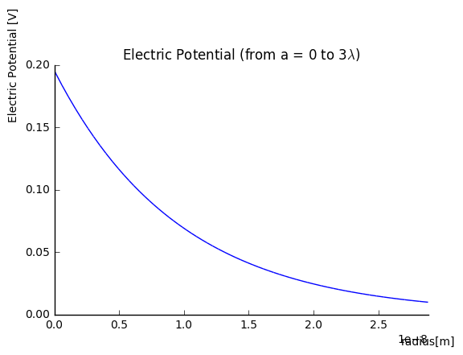

```python
sym.var('r')
sig = 18e-5                # C/m^2   (surface charge density)
zeta = lam*sig/ep          # Volts   (Zeta Potential)

# Electric Potential function(r)
psi = zeta*sym.exp(-r/lam)

print('the zeta potential is {:.3f} V' .format(zeta))
sym.plot(psi,(r,0,3*lam),title='Electric Potential (from a = 0 to 3$\lambda$)',xlabel='radius[m]',ylabel='Electric Potential [V]')

# charge density function(r)
rho_r = ep* sym.diff(sym.diff(psi,r),r)

# charge density in debye layer
rho = sig/lam/2             # C/m^3
```

## 1d) Calculate Streaming Current

Charge is carried in the debye layer due to convective flow. The current density from this effect is: $$ i_{osm} = \rho u = F z (C_+ - C_-) u $$

The streaming current is therefore given by (with constant approximations for u and $\rho$) $$ $$ $$ I_{st} = \int_{a-\lambda}^{a} \rho u 2 \pi r dr $$ $$ $$ $$ I_{st} = \rho u \int_{a-\lambda}^{a} 2 \pi r dr $$ $$ $$ $$ I_{st} = \rho u \left(a^2 - (a-\lambda)^2\right) $$ $$ $$ And the net streaming current is given by: $$ I = I_{st} n_{pores} $$

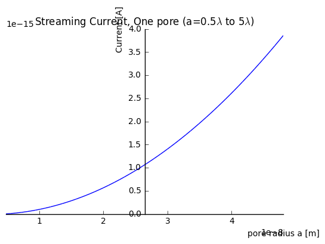

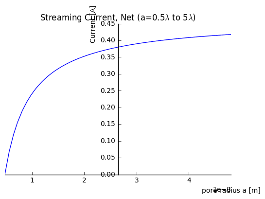

```python
# Streaming Current
def Ist_u(u,a):
    Ist = u*rho*sym.integrate(2*np.pi*r,(r,a-lam,a))  # A
    return Ist

Ist = Ist_u(u,a)

# Net current
I = Ist*npores

#print(Ist)
_ = sym.plot(Ist,(a,0.5*lam,5*lam),title ='Streaming Current, One pore (a=0.5$\lambda$ to 5$\lambda$)',xlabel='pore radius a [m]', ylabel = 'Current [A]')

#print(I)
_ = sym.plot(I,(a,0.5*lam,5*lam),title ='Streaming Current, Net (a=0.5$\lambda$ to 5$\lambda$)',xlabel='pore radius a [m]', ylabel = 'Current [A]')
```

### Analysis of the effect of pore radius on streaming current

The influence of pore radius on streaming current is interesting: Increasing pore radius increases the total volume of fluid in the debye layer (because the inner surface area of the pore increases with a), which increases the streaming current for an individual pore.

At the same time, however, increasing pore size decreases the number of pores and therefore hinders the net streaming current for this membrane. The result is a net streaming current which increases with pore size, but at a decreasing rate (concave down).

## 1e) Calculate Streaming Potential

Streaming Potential is calculated as the stopping voltage of the streaming current. This may be accomplished by setting the net current of the streaming and leak currents to zero: $$ I = I_{st} + I_{leak} = 0 $$

leak current occurs outside of the debye layer and is calculated by: $$ i_{leak} = \frac{-F^2 D}{R T} (C_+ + C_-) \frac{d\phi}{dx} $$

outside of the debye layer, $\rho$ = 0, and thus the leak current density simplifies to: $$ i_{leak} = \frac{-2 F^2 D C }{R T} \frac{d\phi}{dx} $$

Total leak current is therefore: $$ I_{leak} = \int_{0}^{a-\lambda} \frac{-2 F^2 D C }{R T} \frac{d\phi}{dx} 2 \pi r dr $$

Assuming a constant Electric Field, this integral is: $$ I_{leak} = \frac{-2 F^2 D C }{R T} \frac{\Delta\phi_{st}}{L} (a-\lambda)^2 $$ $$ $$ $$ I = I_{st} + I_{leak} = 0 $$ $$ $$ $$ \frac{2 F^2 D C }{R T} \frac{\Delta\phi_{st}}{L} (a-\lambda)^2 = I_{st} $$ $$ $$ $$ \Delta\phi_{st} = I_{st} \frac{R T L}{2 F^2 D C \pi (a-\lambda)^2} $$

Furthermore, the Power generated by this single Reverse Electrodialysis membrane may be calculated by: $$ P_{out} = I_{st} V_{st} n_{pores} $$

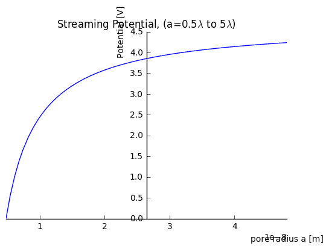

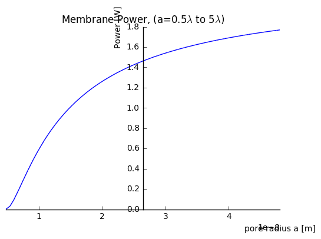

```python
def Vst_Ist(Ist,a):
    Vst = Ist*R*T*L/(2*F*D*Cs*np.pi*a**2)
    return Vst

Vst = Vst_Ist(Ist,a)
_= sym.plot(Vst,(a,0.5*lam,lam*5),title ='Streaming Potential, (a=0.5$\lambda$ to 5$\lambda$)',xlabel='pore radius a [m]', ylabel = 'Potential [V]')


Pout = Ist*Vst*npores
_= sym.plot(Pout,(a,0.5*lam,lam*5),title ='Membrane Power, (a=0.5$\lambda$ to 5$\lambda$)',xlabel='pore radius a [m]', ylabel = 'Power [W]')
```

### Analysis of the effect of pore radius on Power output

Similar to streaming current, output power increases with increasing pore size- quicky at first, due to the gain in streaming current flux area, but later dampened by the loss in pore density. Furthermore, as pore radius increases, the necessary stopping voltage (streaming potential) flattens out because all the ions in the pore (not just the excess charge in the debye layer) contribute to the stopping potential. This results in a decreasing marginal gains for the power output as pore radius is increased.

## 1f) Calculate Hydrodynamic power

Total Power input is defined by the hydrodynamic power generated by osmotic flow.
This flow is calculated by: $$ P_{out} = Q_{osmotic} \Delta P_{osmotic} $$

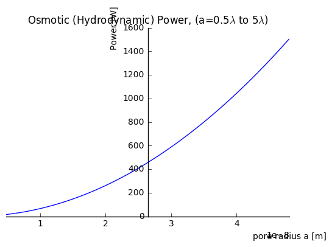

```python
Pin = Q*dP*npores
_ = sym.plot(Pin,(a,0.5*lam,5*lam),title ='Osmotic (Hydrodynamic) Power, (a=0.5$\lambda$ to 5$\lambda$)',xlabel='pore radius a [m]', ylabel = 'Power [W]')
```

### Analysis of the effect of pore radius on Hydrodynamic Power

Power from osmotic pressure increases quadratically with pore radius.

## 1g) Efficiency

Efficiency of the cell is given by the power output (streaming) over the power input (hydrodynamic osmotic flow)

$$ efficiency = \frac{P_{out}}{P_{in}} *100 [\%]$$

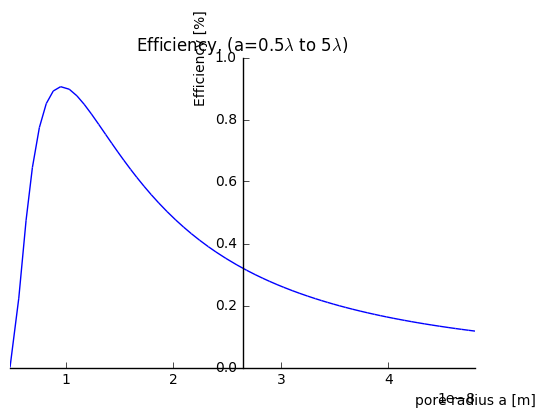

```python
eff = Pout/Pin*100                # %
_= sym.plot(eff,(a,lam/2,lam*5),title ='Efficiency, (a=0.5$\lambda$ to 5$\lambda$)',xlabel='pore radius a [m]', ylabel = 'Efficiency [%]')
```

### Calculate maximum efficiency, optimal pore radius

```python
deriv = sym.diff(eff,a)
a_opt = sym.solve(deriv,a)

I_opt = I.evalf(subs={a:a_opt[1]})
Vst_opt = Vst.evalf(subs={a:a_opt[1]})
Pout_opt = Pout.evalf(subs={a:a_opt[1]})
eff_opt = eff.evalf(subs={a:a_opt[1]})

print('The optimum pore size is {:.3f} nm, the size of the debye layer' .format(a_opt[1]*10**9))
print('This produces a maximum efficiency of {:.3f} %' .format(eff_opt))
print('At the optimal pore size, the cell current is {:.3f} A' .format(I_opt))
print('At the optimal pore size, the streaming voltage is {:.3f} V' .format(Vst_opt))
print('At the optimal pore size, the streaming power is {:.3f} W' .format(Pout_opt))
```

```
The optimum pore size is 9.610 nm, the size of the debye layer
This produces a maximum efficiency of 0.906 %
At the optimal pore size, the cell current is 0.232 A
At the optimal pore size, the streaming voltage is 2.353 V
At the optimal pore size, the streaming power is 0.546 W
```

### Analysis of the effect of pore radius on efficiency

The optimal pore radius is determined to be the debye length.  
While increasing the pore radius will always result in a higher power output, these increases are dampened by the loss in pore density and decreasing gains in streaming potential. As a result, the quadratic increase in hydrodynamic power input eventually overtakes the growing power output and creates an optimal pore radius equal to the debye length. At radii larger than the debye length, hydrodynamic power, pore density, and streaming potential limit efficiency, while at radii smaller than the debye length, the full amount of power from streaming potential (excess charge) is not being realized.

The maximum achievable efficiency with this model is 0.906%. This is not a very high efficiency, but the streaming potential is essentially free. The only costs are capital (PPE, membrane R&D, etc.), and pumping. The latter will be analyzed in part 2.

# Part 2: Optimize Energy Output: Optimal Channel Width and Flowrate

The second part of this project completes the design of an electrodialysis plant by optimizing the flowrate and channel thickness of the two feed streams while minimizing pumping energy costs. The metric for this optimiztion process is (net) Energy output per unit area.

While inexpensive, low flowrates will lead to dilution of the saltwater stream, leading to decreased osmotic pressure and therefore decreased power output. An optimal flowrate will therefore minimize the dilution effects while also minimizing pumping energy costs. Further, decrease in channel width will increase flowrate (and therefore power output, to an extent) but also increase pumping energy costs.

All the preceding calculations have been for a single membrane separating saltwater and freshwater. The following flow calculations will be made for a single channel (of either saltwater or freshwater composition); thus, the overall results are easily scalable.

### Define (updated) flow calculation function

models flow in cylindrial pore, now with the optimal pore size a = lambda

```python
def Flow(dP):
    Q = dP*np.pi*lam**4/(8*mu*L)     # m^3/s   (Volumetric Flowrate)
    umax = dP*lam**2/(4*mu*L)        # m/s     (maximum fluid velocity)
    u = 0.5*umax                     # m/s     (fluid velocity in debye layer)
    return [u,Q]
```

## 2a) Mass Balance

Dilution Effects will be analyzed by a mass balance along the length of the column. Only the saltwater stream determines the osmotic pressure, so only the mass balance on the saltwater stream needs to be calculated.

Saltwater stream mass balance: (The saltwater stream experiences mass flow from membranes on both sides, so the flowrate entering from the membranes will be twice the osmotic flowrate calculated in part 1f.) $$ Q_{in} + 2Q_{osm} = Q_{out} $$ $$ Q_{in}C_{in} + 2Q_{osm}C_{osm} = Q_{out}C_{out} $$ $$ $$ $$ C_{in} = C_{salt} $$ $$ C_{osm} = C_{water} $$ Solving for the outflow concentration yields the equation: $$ C_{out} = \frac{Q_{in}C_{in} + 2Q_{osm}C_{osm}}{Q_{out}} $$ This concentration may be used to calculate the Osmotic pressure (and therefore power output) at the end of the column.

These calculations assume an osmotic flow through the membrane which does not vary along the length of the column. The full differential equations could be modeled, however the constant assumption will be valid for flowrates in which the osmotic pressure does not substantially change over the length of the column (<5% decrese) - which is desired in this design. Optimal flowrates will therefore be limited to the domain where exit concentration is approximately greater than 0.95*Cs (0.95M).

```
minimum flowrate is 0.000937148217636
```

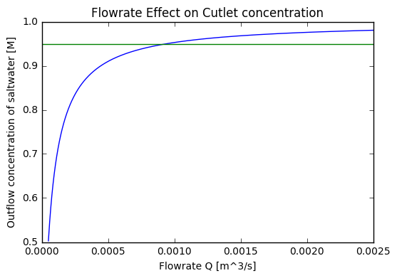

```python
# Model Dilution (Mass Balance)
def Mass_Bal(w):
    # set up vector of inlet flowrates
    t = np.linspace(2,100,1000)           # s  (flowrate timescales, 1 to 60s)
    Qin = Area*w/t
    Cin = Cs                              # moles/m^3 (inlet Concentration is the Salt Stream Concentration)

    # calculate osmotic flowrate
    [u,Q] = Flow(P_osm(Cin))
    Qosm = Q*npores.evalf(subs={a:lam})   # m^3/s  (total flowrate across all pores)
    Cosm = Cf                             # moles/m^3 (osmotic flow is fresh Stream Concentration)

    # Calculate outlet flowrate and Concentration.
    Qout = Qin + 2*Qosm
    Cout = (Qin*Cin + 2*Qosm*Cosm)/Qout

    return [Cout,Qin]

# Find minimum flowrate based on threshold dilution of 5%
def Q_lower(Cout,Qin):
    Cmax = 0.95*Cs
    index = next(x[0] for x in enumerate(Cout) if x[1] < Cmax)
    Qmin = Qin[index]

    return index,Qmin


# calculate outlet concentration at all flowrates for given channel width:
w = 5/1000              # m  (channel width, 10mm)
[Cout,Qin] = Mass_Bal(w)

# Calculate minimum flowrate
[index,Qmin] = Q_lower(Cout,Qin)

print('minimum flowrate is',Qmin)
_ = plt.plot(Qin,Cout/1000)
_ = plt.plot([0,np.max(Qin)],[Cmax/1000,Cmax/1000])
_ = plt.title('Flowrate Effect on Cutlet concentration')
_ = plt.xlabel('Flowrate Q [m^3/s]')
_ = plt.ylabel('Outflow concentration of saltwater [M]')
#_ = plt.legend(['Outlet Concentration','Minimum Dilution', 'location','northoutside'])
```

## 2b) Dilution Effect on Power Output

The power output is calculated using the average of the inlet and outlet osmotic pressures. This assumption is valid in the domain where there is minimal dilution effects; the drop in osmotic pressure will be approximately linear across the length of the column for this flowrate domain (0.546 W for this particular setup).

In addition, the lower bound for the flowrate is established at 5% dilution.

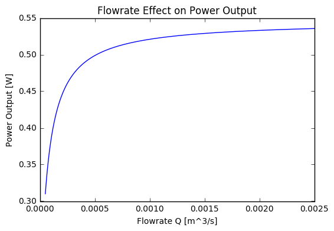

```python
# Calculate Reverse Electrodialysis Power output factoring in Dilution effects
def Power(Cout):
    # calculate osmotic pressure at start and end of column
    dPout = P_osm(Cout)
    dPin = P_osm(Cs)

    # Average osmotic pressure over length of column
    dPavg = (dPin + dPout)/2

    # Model Membrane, calculate power
    [u,Q] = Flow(dPavg)
    Ist = Ist_u(u,lam)
    Vst = Vst_Ist(Ist,lam)
    Pout = Ist*Vst*npores.evalf(subs={a:lam})

    return Pout

Pout = Power(Cout)

_ = plt.plot(Qin,Pout)
_ = plt.title('Flowrate Effect on Power Output')
_ = plt.xlabel('Flowrate Q [m^3/s]')
_ = plt.ylabel('Power Output [W]')
```

## 2c) Pumping Energy Cost, Energy Generation Comparison

The energy to pump fluid through the apparatus is; $$ E_{pump} = Q_{in} \Delta P_{pump} $$ $$ $$ pressure drop may be calculated using the Reynolds number and Darcy friction factor, for turbulent flow: $$ D_h = \frac{4A}{P} $$ $$ $$ $$ Re = \frac{\rho u D_{h}}{\mu} $$ $$ $$ $$ f = 0.079 Re^{-0.25} $$ $$ $$ $$ \Delta P_{pump} = \frac{2 f L \rho u^2}{D_h} $$

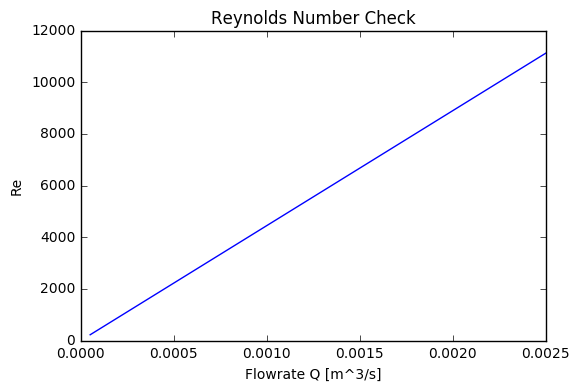

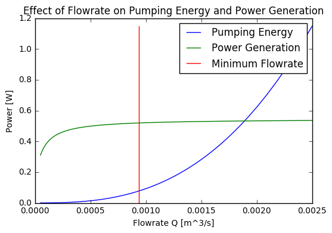

```python
def Pump(Qin):
    v = Qin/(w*l)            # m/s    (fluid velocity)
    p = 1000                 # kg/m^3 (density of water)

    A = w*l                  # m^2    (channel area)
    P = 2*(w+l)              # m      (channel perimiter)
    Dh = 4*A/P               # m      (Hydraulic Diameter- in this case, approaches 2*w)

    Re = p*v*Dh/mu           #        (Reynold's Number)

    f = 0.079*Re**(-0.25)    #        (friction factor)

    dPump = f*l*2*p*v**2/Dh  # Pa     (Pressure Drop)

    E = dPump*Qin            # W      (Pumping Energy)
    return E

E_pump = Pump(Qin)

_ = plt.figure(1)
_ = plt.plot(Qin,Re)
_ = plt.title('Reynolds Number Check')
_ = plt.xlabel('Flowrate Q [m^3/s]')
_ = plt.ylabel('Re')


_ = plt.figure(2)
_ = plt.plot(Qin,E_pump)
_ = plt.plot(Qin,Pout)
_ = plt.plot([Qmin,Qmin],[0,np.max(E_pump)])
_ = plt.title('Effect of Flowrate on Pumping Energy and Power Generation')
_ = plt.xlabel('Flowrate Q [m^3/s]')
_ = plt.ylabel('Power [W]')
_ = plt.legend(['Pumping Energy','Power Generation','Minimum Flowrate'])
```

### Flowrate Effects on Power

The second figure plots both the RED Power generation and the Pumping energy costs, as well as the minimum allowable flowrate. It appears that as flowrate increases, the pumping energy costs increase and eventually exceed power generation. The point where these two lines intersect is the upper bound on flowrate. Maximum net energy production is produced at the minimum allowable flowrate.

Manipulation of channel width indicates two opposing phenomenon:  
increasing channel width decreases pumping energy costs but would decrease the energy output per area of the cell.  
decreasing channel width increases pumping energy costs (to the point that they eventually exceed power generation), but would increase the energy output per area of the cell.

As a result, the energy output per area of the cell will be calculated for varying channel widths.

### Energy Output per Area

The energy per unit area is calculated at the loweset possible flowrate so as to maximize the difference between Pumping energy and Power generation (net power).  
Footprint is calculated as: length * (width + membrane thickness)

```python
def E_area(w,index,Pout,E_pump):
    P_gen = Pout[index] - E_pump[index]    # W     (Net power)
    SA = l*(w+L)                           # m^2   (Area, footprint)
    E = P_gen/SA                           # W/m^w (Net power per unit area)
    return E

E_output = E_area(w,index,Pout,E_pump)
print('Energy output',E_output, 'Watts per square meter for channel width', w ,'m')
```

```
Energy output 73.6896585947098 Watts per square meter for channel width 0.005 m
```

## 2d) Calculate Energy Output per area as a function of channel width, flowrate

### define overall model function

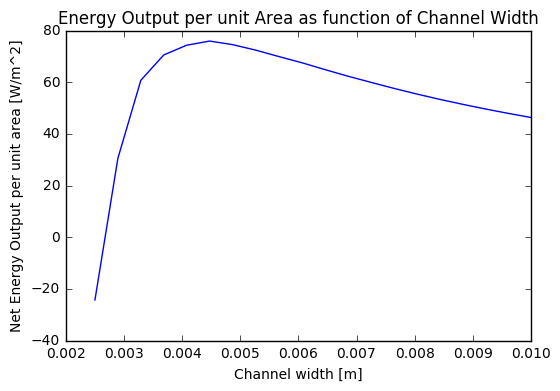

```python
def model(w):
    [Cout,Qin] = Mass_Bal(w)                  # Use Mass Balance to Calcualte Concentration Profile and Flowrate
    [index,Qmin] = Q_lower(Cout,Qin)          # Calculate optimal (lower bound) flowrate

    Pout = Power(Cout)                        # Calculate Power output as a function of Flowrate, given the Concentration profile
    E_pump = Pump(Qin)                        # Calculate Pumping energy costs as a function of Flowrate

    E_output = E_area(w,index,Pout,E_pump)    # Calculate Energy puer unit area at optimal flowrate

    return E_output


# calcuate Energy per unit area as a function of
w_lower = 2.5/1000            # for channel widths from 2.5 mm
w_upper = 10/1000             # to 10 mm
w_vec = np.linspace(w_lower,w_upper,20)

E_output = np.array(np.zeros(len(w_vec)))
for i,w in enumerate(w_vec):
    E_output[i] = model(w)

plt.plot(w_vec,E_output)
plt.title('Energy Output per unit Area as function of Channel Width')
plt.xlabel('Channel width [m]')
plt.ylabel('Net Energy Output per unit area [W/m^2]')
```

### Increase Resolution

```python
# calculate Energy output for channel widths from 3.5 to 5 mm
w_vec2 = np.linspace(3.5/1000,5/1000,21)

E_output2 = np.array(np.zeros(len(w_vec2)))
for i,w in enumerate(w_vec2):
    E_output2[i] = model(w)
```

### Calculate Maximum Energy Output, Optimal Channel Width

```python
E_max = max(E_output2)
w_max = w_vec2[np.argmax(E_output2)]

w_max_mm = w_max*1000

print('Maximum Energy output is {:.2f} W/m^2' .format(E_max))
print('The optimal channel width is {:.2f} mm' .format(w_max_mm))
```

```
Maximum Energy output is 75.90 W/m^2
The optimal channel width is 4.47 mm
```

This optimization completes the design of the RED channels. They can be scaled infinitely to gain a variety of power outputs at the cost of a larger footprint.

# Analysis of Scale

A singe cubic meter cell consisting of 182 membrane-separated channels can power 7.5 10 Watt lightbulbs.

A study by the city of Amsterdam stated that the city used 54,500 Terajoules of energy in 2015.  
Using this data, $\textbf{a RED facility of 22.8 square kilometers would power the entire city of Amsterdam.}$  
To give a sense of scale, a factory this size would be 23 times larger than Tesla's Gigafactory (1 sq km).

In the same study, the city of Amsterdam has plans to increase their solar energy production from 9MW to 160 MW from 2013 to 2020. For RED to have equal (160MW) power generation it would require a factory 2 sqare kilometers - Or one gigafactory with two floors.

A typical large warehouse of 10,000 m^2 can produce 0.75 Mpa of power. With several stacked layers of cells, this could exceed 3 MPa, enough energy to power 1,500 Amsterdam Households.

Calculations below:

```python
# units per m^3
n_membranes = 1 / (w_max + L)
print('number of membranes in one cubic meter RED Cell:',n_membranes,'membranes/m^3')

Amst_E = 54500e12                     # J   (total energy consumption of Amsterdam, annually: 54,500 TeraJoules)
Amst_P = Amst_E / (365*24*3600)       # W   (Necessary Power supply to Amsterdam)

Amst_Area = Amst_P/E_max              # m^2   (Area needed to Power Amsterdam with RED)
Amst_Area_km = Amst_Area / (1000)**2  # km^2  (Area needed, square km)

print('Area required to power amsterdam:', Amst_Area_km, 'km^2')


Solar_Amst = 160e6                     # W     (projected solar production, amsterdam, 2020: 160MW)
Solar_Area = 160e6/E_max               # m^2   (Area needed for RED to equal solar power in Amsterdam
Solar_Area_km = Solar_Area /(1000)**2  # km^2  (Area needed, square km)

print('Area required to match solar production in 2020:', Solar_Area_km, 'km^2')


Warehouse_Area = 1e4                   # typical large warehouse size: 10,000m^2
Warehouse_Power = Warehouse_Area*E_max # Warehouse output

print('Power output of typical large warehouse', Warehouse_Power)
```

```
number of membranes in one cubic meter RED Cell: 182.648401826 membranes/m^3
Area required to power amsterdam: 22.7697048104 km^2
Area required to match solar production in 2020: 2.10808194025 km^2
Power output of typical large warehouse 758983.780207
```

# Conclusion

This project investigated the design of a Reverse Electrodialysis power generation plant:

in Part 1, Pore size was optimized such that the maximum amount of hydrodynamic power was extracted as energy. The optimal pore size was determined to be the debye length. The maximum attainable efficiency was determined to be 0.91%

Analysis of scale shows that despite RED being infinitely scalable, it still requires a very large footprint to compete with other sources of energy generation. Ultimately, though osmotic pressure is a promising source of power, RED has low efficiencies. Furthermore, it is only really applicable in areas where freshwater and saltwater contact, such as the emptying of a river into the sea.

Further analysis may be made by modelling the full differential equations for fluid flow along the length of the column to investigate flow regimes which have higher dilution but may produce higher Energy per unit area.